# VAR_OP

```python
import numpy as np
import pandas as pd
import seaborn as sns
```

1 **Wyjaśnić jakie ryzyko mierzy ryzyko operacyjne.?**

- Ryzyko straty które powstaje przez niewłaściwe lub zawodne procesy wewnętrzne w firmie np. przyjęcie fałszywego banknotu przez pracownika , oszustwa wewnętrzne, wyciek informacji z banku, lawsuity o dyskryminacje

2 **Na podstawie treści z wykładu (oraz ew. innych wiarygodnych źródeł) wyjaśnić, jak obecnie wyznacza się ryzyko operacyjne w bankach. Dlaczego metoda rozkładu strat (LDA) nie jest uważana za optymalną?**

Ponieważ bazylea nie pozwala tego stosowac od 2023 roku z uwagi na to,że :

- Trudnosc symulacji dopasowania danych banki czesto nie mialy odpowiedniej ilosci danych i wiele innych problemów z ktorymi banki musialy sie mierzyc zeby zbudowac te historyczne dane, przez to nie jest w pelni wiarygodny
- Jesli zaden rozklad nie pasuje mozemy wybrac ten ktory ma mniejsze ogony, pod wzgledem wymogów kapitałowych banki mogly manipulowac troche wynikami i przez to zanizac wymogi kapitalowe . Przez to w 2023 wprowadzono metode SMA, ktora ma zastepowac np BIA ,TSA i najwazniejsze AMA . Metoda SMA ma prostsza metodologie, lepszą porównywalność między bankami oraz mniejszą podatność na manipulacje.
- Metoda SMA polega na 2 glownych zalozeniach : wiekszy bank wieksze ryzyko operacyjne , wieksze straty w przeszlosci -> większy wymóg kapitałowy w przyszlosci. SMA oblicza sie jako = BIC (skala dzialalnosci) * ILM (poziom strat z historii). Te wskaźniki oblicza się na podstawie danych z ksiąg dzieki temu jest mniej podatna na manipulacje.

```python
data = pd.read_csv('plik18.csv')
```

```python
data.drop(columns=['Unnamed: 0'], inplace=True)
```

```python
data['linia'].value_counts()
```

```
Empl_Pract     2642
Internal_Fr    2002
Execut_Del      524
Buss_Distr      516
Com_Ban         484
Damage          402
External_Fr     203
Name: linia, dtype: int64
```

## krótka EDA

```python
# wykresy stat opisowe tabelki
```

```python
dane = data[data['linia'].isin(['Buss_Distr','Com_Ban'])]
```

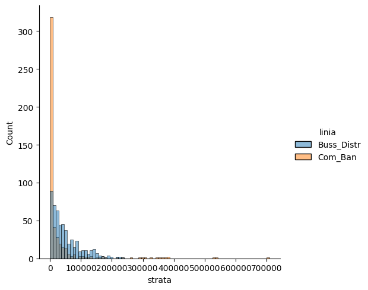

```python
sns.displot(data=dane, x='strata', hue='linia', kind='hist')
```

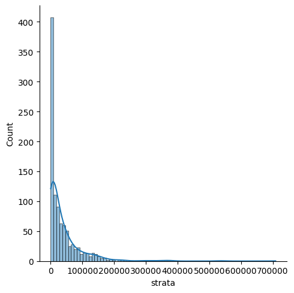

```python
sns.displot(data=dane, x='strata',kind='hist',kde=True) # caly wykres polaczone  + estymator gestosci
```

```python
dane.groupby('linia')['strata'].describe().T.round(2)
```

| linia | Buss_Distr | Com_Ban |
| --- | --- | --- |
| count | 516.00 | 484.00 |
| mean | 50000.00 | 27000.26 |
| std | 47453.79 | 73012.86 |
| min | 47.15 | 10.00 |
| 25% | 14328.08 | 486.74 |
| 50% | 36016.12 | 3393.94 |
| 75% | 68812.30 | 19798.91 |
| max | 230449.02 | 708928.30 |

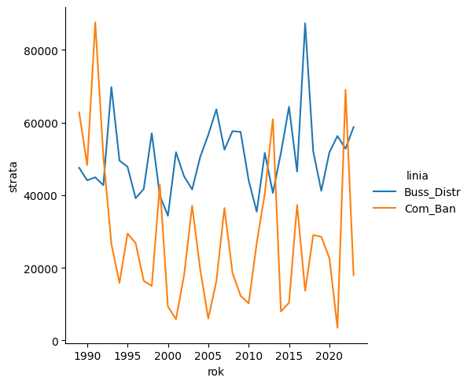

```python
sns.relplot(data=dane, x='rok', y='strata', hue='linia',kind='line',errorbar=None)
```

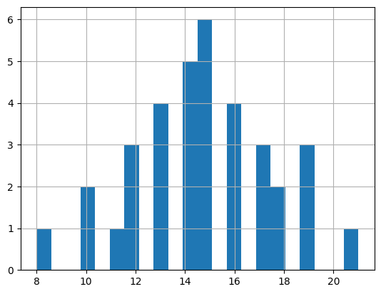

```python
dane.query("  linia == 'Buss_Distr'   ").groupby('rok')['strata'].count().hist(bins=int(np.sqrt(516)))
```

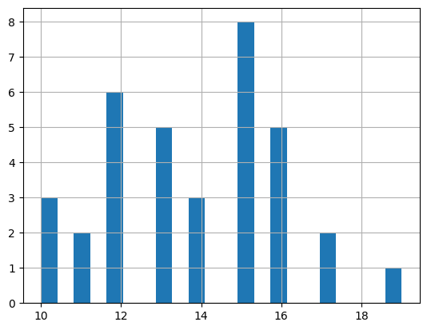

```python
dane.query("  linia == 'Com_Ban'   ").groupby('rok')['strata'].count().hist(bins=int(np.sqrt(484)))
```

- na przestrzeni lat wystapila strata średnio większa dla Buss_Distr niz dla Comb_Ban.
- rozklady strat linii biznesowych przypominają rozkład lognormalny.
- wystapienia w latach tych strat sa dosyc do siebie podobne pod wzgledem czestosci .

# dopasowanie zgodnosci danych z rozkladem częstości strat.

```python
dane.query("  linia == 'Buss_Distr'   ")
```

|  | rok | strata | linia |
| --- | --- | --- | --- |
| 0 | 1989 | 52340.11 | Buss_Distr |
| 1 | 1989 | 15865.20 | Buss_Distr |
| 2 | 1989 | 3834.25 | Buss_Distr |
| 3 | 1989 | 30208.66 | Buss_Distr |
| 4 | 1989 | 177120.64 | Buss_Distr |
| ... | ... | ... | ... |
| 511 | 2023 | 36444.41 | Buss_Distr |
| 512 | 2023 | 27588.63 | Buss_Distr |
| 513 | 2023 | 22679.61 | Buss_Distr |
| 514 | 2023 | 100763.72 | Buss_Distr |
| 515 | 2023 | 4780.37 | Buss_Distr |

516 rows × 3 columns

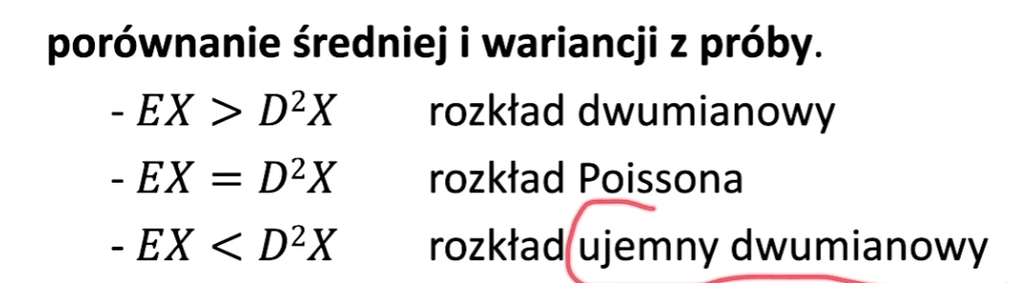

- na tej podstawie przyjalem rozklad dyskretny dla czestosci strat

# dopasowywanie rozkładu dla Buss_Distr

**WAZNE**

- Python ma braki z w bibliotekach dlatego zrobilem na zgodnosc z rozkladem uniform PIT (Probability Integral Transform).

## rozklad czestosci strat

```python
rozklad_cz_s_buss = dane.query("  linia == 'Buss_Distr'   ").groupby('rok')['strata'].count().reset_index()
```

```python
np.mean(rozklad_cz_s_buss['strata'])
```

```
14.742857142857142
```

```python
np.var(rozklad_cz_s_buss['strata'],ddof=1)
```

```
8.196638655462186
```

- wybieram rozklad dwumianowy

n =35

- sa 2 mozliwosci do oszacowania parametrów rozkladu, które znalazłem
- 1 metoda numeryczna, która szuka MAX -Log likelihood aby dopasowac jak najlepiej paramy (z biblio scipy podana poniżej) ,która szuka na predziale gdzie: deafultowo p szuka w przediale od (0,1), natomiast boundy dla n (maksymalna liczbe zdarzen w roku) trzeba podac jako przedział. Ja założyłem ,że górny przedzial powinen być na mju+3*Sigma,natomiast dolny jako max wartosc z wystąpien w roku
- 2 sposob na oszacowanie to wedlug wzorów, które

$\mu = np$

$\sigma^2 = np(1-p)$

$\hat{p} = 1 - \frac{\sigma^2}{\mu}$

$\hat{n} = \frac{\mu}{\hat{p}}$

zrodlo : https://math.stackexchange.com/questions/2474197/using-method-of-moments-on-binomial-distribution?utm_source

```python
from scipy import stats

countsy = rozklad_cz_s_buss["strata"]

osz = stats.fit(stats.binom,countsy,bounds={"n": (max(countsy), 23)})


print(f"n = {osz.params.n}")
print(f"p = {osz.params.p}")
```

```
n = 23.0
p = 0.6409937916039704
```

```python
print( np.mean(rozklad_cz_s_buss['strata'])/ ( 1- np.var(rozklad_cz_s_buss['strata']) / np.mean(rozklad_cz_s_buss['strata']) ))
```

```
32.05586323139899
```

- **wybralem metode numeryczną z uwagi na duze odchylenie od sredniej dla 2 metody i również ja zastosuje w 2 rozkladzie dla zgodnosci**

```python
np.mean(countsy) +3*np.std(countsy) # 3 sigma rule
```

```
23.208200657229526
```

## rozklad dotkliwosci strat

- jak bardzo ta strata bedzie dotkliwa

```python
straty = dane.query("linia == 'Buss_Distr'")["strata"]

paramy = stats.lognorm.fit(straty, floc=0)

fitted_dane = stats.lognorm.cdf(straty, *paramy) # wypakowuje

cramer_buss_pit = stats.cramervonmises(fitted_dane, "uniform")

print(f"stat_testu {cramer_buss_pit.statistic} pval {cramer_buss_pit.pvalue}")
```

```
stat_testu 1.1867019481129497 pval 0.000896211968233307
```

- brak lognormal

```python
wyniki_1 = []

rozkłady = [("wykładniczy", "expon", stats.expon), ("Weibulla", "weibull_min", stats.weibull_min), ("Pareto", "pareto", stats.pareto)]

for name, scip, rozklad in rozkłady:
    paramy2 = rozklad.fit(straty, floc=0)

    u = rozklad.cdf(straty, *paramy2) # again wypakowanie

    test = stats.cramervonmises(u, "uniform")

    wyniki_1.append([name, test.statistic, test.pvalue, paramy2])

wyniki_df_1 = pd.DataFrame(wyniki_1, columns=["dist", "stat_testu", "pval", "paramy"])

display(wyniki_df_1)
```

|  | dist | stat_testu | pval | paramy |
| --- | --- | --- | --- | --- |
| 0 | wykładniczy | 0.053091 | 8.575072e-01 | (0.0, 49999.999767441856) |
| 1 | Weibulla | 0.053128 | 8.572810e-01 | (1.00007979280022, 0, 50001.63995206731) |
| 2 | Pareto | 32.038559 | 1.659500e-08 | (0.15679577653146107, 0, 47.15) |

- na tej podstawie wybieram rozkład wykladniczy dla linii Buss_Distr dla dotkliwosci strat
- chociaz moge również Weibulla.

# dopasowywanie rozkładu dla Com_Ban

## rozklad dotkliwosci strat

```python
straty_2 =  dane.query("linia == 'Com_Ban'")["strata"]
```

```python
params3 = stats.lognorm.fit(straty_2, floc=0)

u2 = stats.lognorm.cdf(straty_2, *params3)

test_cvm2 = stats.cramervonmises(u2, "uniform")

print(f"stat = {test_cvm2.statistic} pavl = {test_cvm2.pvalue}")
```

```
stat = 0.44171072693785507 pavl = 0.05615479631055764
```

- na granicy 5% log normal

```python
wyniki_2 = []

rozkłady = [("wykładniczy", "expon", stats.expon), ("Weibulla", "weibull_min", stats.weibull_min), ("Pareto", "pareto", stats.pareto)]

for nazw, scip2, dist in rozkłady:
    params = dist.fit(straty_2, floc=0)

    u2 = dist.cdf(straty_2, *params)

    test = stats.cramervonmises(u2, "uniform")

    wyniki_2.append([nazw, test.statistic, test.pvalue, params])

wyniki_df_2 = pd.DataFrame(wyniki_2, columns=["dist", "stat_testu", "pval", "paramy"])

display(wyniki_df_2)
```

|  | dist | stat_testu | pval | paramy |
| --- | --- | --- | --- | --- |
| 0 | wykładniczy | 32.383266 | 2.560742e-09 | (0.0, 27000.256115702476) |
| 1 | Weibulla | 0.115204 | 5.155181e-01 | (0.42807574418928807, 0, 8989.129686528586) |
| 2 | Pareto | 11.067490 | 2.504051e-10 | (0.18138880014653977, 0, 10.0) |

- przujmuje Weibulla ponieważ istoność lognormal graniczna na 5%

## rozklad czestosci

```python
rozklad_cz_s_comban = dane.query("  linia == 'Com_Ban'   ").groupby('rok')['strata'].count().reset_index()
```

```python
np.mean(rozklad_cz_s_comban['strata'])
```

```
13.82857142857143
```

```python
np.var(rozklad_cz_s_comban['strata'],ddof=1)
```

```
4.852100840336133
```

- podobnie jak w przypadku buss wybieram dwumianowy

```python
from scipy import stats

countsy2 = rozklad_cz_s_comban["strata"]

osz2 = stats.fit(stats.binom,countsy2,bounds={"n": (max(countsy2), 23)})


print(f"n = {osz2.params.n}")
print(f"p = {osz2.params.p}")
```

```
n = 21.0
p = 0.6585034034227645
```

# OpVar

## linia BUSS DISTR

- częstosc rozklad : dwumianowy ,pararmy n=23 ,phat = 0.64:
- dotkliwosc roklad : wykladniczy, param lambda okolo : 1/ 50000. (przesuniecie rowniez zero floc param = 0)

(scale zwraca odwrotnosc lambdy) : https://docs.scipy.org/doc/scipy/reference/generated/scipy.stats.expon.html?utm_source

## generowanie dwumianowy

```python
from scipy.stats import binom


data_binom_buss = binom.rvs(23, p=0.64, size=10000, random_state=42)
```

```python
losowanie =pd.DataFrame({'binom_buss':data_binom_buss})
```

```python
losowanie
```

|  | binom_buss |
| --- | --- |
| 0 | 16 |
| 1 | 11 |
| 2 | 13 |
| 3 | 14 |
| 4 | 17 |
| ... | ... |
| 9995 | 12 |
| 9996 | 12 |
| 9997 | 11 |
| 9998 | 15 |
| 9999 | 17 |

10000 rows × 1 columns

## generowanie wykladniczy

```python
from scipy.stats import expon
```

```python
losowanie['scenariusze'] = losowanie['binom_buss'].apply(lambda d: np.sum(expon.rvs(loc=0, scale=50000, size=d, )))
```

## linia Com_Ban

- częstosc rozklad : dwumianowy, pararmy n= 21 oraz phat = 0.66 :
- dotkliwosc roklad : Weibulla, paramy : paramy : (0.42807574418928807, 0, 8989.129686528586)
- (usatawilem floc=0 zatme przesuniecie 0 ) , natomiast k = 0.43 (scipy c) a lambda = 8989 ( w scipy scale)

99.9% AMA( LDA) Najczesciej na 1 rok

## generowanie dwumianowy

```python
from scipy.stats import binom
```

```python
losowanie['binom_comban'] = binom.rvs(21, p=0.66, size=10000, random_state=42)
```

## generowanie Weibulla

```python
from scipy.stats import weibull_min

losowanie['scenariusze_2'] = losowanie['binom_comban'].apply(lambda d: np.sum(weibull_min.rvs(c=0.43,loc=0,scale=8989.13,size=d,)))
```

```python
losowanie['suma'] = losowanie['scenariusze'] + losowanie['scenariusze_2']
```

```python
var_999 = np.quantile(losowanie['suma'],q=0.999)
```

```python
print( f" VAR 99.9% {np.quantile(losowanie['suma'],q=0.999)}  ES 99.9% {losowanie.loc[losowanie['suma'] >= var_999, 'suma'].mean()}  ")
```

```
 VAR 99.9% 2975835.0331132906  ES 99.9% 3475296.149291324
```